# Practical machine learning

## Introduction / Summary

Electronic watches can collect a large amount of data about ones personal activities. These type of devices are taking measurements about physical activities to improve health, to find patterns in behavior, etc. People quantify regularly how much of a particular activity they do, but they rarely quantify how well they do it. In this project, the data from accelerometers on the belt, forearm, arm, and dumbell of 6 participants will be used. They were asked to perform barbell lifts correctly and incorrectly in 5 different ways. The datasets required for the present assignment is given by courtesy from http://groupware.les.inf.puc-rio.br/har.

## Purpose

The goal is to predict the manner in which the participants did the exercise, which you find in the “classe” variable in the training set and predict it using the different parameters as predictors. Different models will be used and the one that suits best the data will be selected and used on the testing dataset.

## Datasets

The training and testing datasets are downloaded and loaded to R environment.

```r
fileurl_training <- "https://d396qusza40orc.cloudfront.net/predmachlearn/pml-training.csv"
fileurl_testing <- "https://d396qusza40orc.cloudfront.net/predmachlearn/pml-testing.csv"
download.file(fileurl_training, destfile = "pml-training.csv", mode = "wb")
download.file(fileurl_testing, destfile = "pml-testing.csv", mode = "wb")
training <- read.csv("pml-training.csv", header = TRUE, na.strings = c("", "NA"))
testing <- read.csv("pml-testing.csv", header = TRUE, na.strings = c("", "NA"))
```

## Exploraatory analysis

An overview of the dataset training is first performed. The dataset contains many columns that contains missing values. In order to reduce the analysis to essentials parameters, columns that contains more than 90% of missing values are removed, as well as the one that contains participants information.

```r
library(dplyr, warn.conflicts = FALSE)
dim(training)
head(training)
missing_values <- vector()
for(i in 1:dim(training)[2]){missing_values[i] <- 100 * mean(is.na(training[,i]))}
training <- training[, which(missing_values < 90)]
training <- training[, -c(1:7)]
training$classe <-  as.factor(training$classe)
str(training)
testing <- testing[, which(missing_values < 90)]
testing <- testing[, -c(1:7)]
```

[output not shown]

## Predicition models

Since the training set is a large data frame, it will be subdivided into a training set and a cross validation test set prior using the model to the testing set.

```r
library(caret)
library(e1071)
trainIndex = createDataPartition(y= training$classe,p=0.75,list=FALSE)
training_new = training[trainIndex,]
cross_valid = training[-trainIndex,]
```

Different classification algorithm are tested in parallel. The model selected are decision tree, random forest, bossting and a linear model. Each of the following subsection is dedicated to one model. The models are tested on the cross validation dataset created above.

### Classification tree

```r
set.seed(1234)

modFit0 <- train(classe ~., method ="rpart", data=training_new)
pred0 <- predict(modFit0, cross_valid)
confusionMatrix(pred0, cross_valid$classe)$overall["Accuracy"]
```

```
##  Accuracy
## 0.5077488
```

```r
library(rattle, warn.conflicts = FALSE)
```

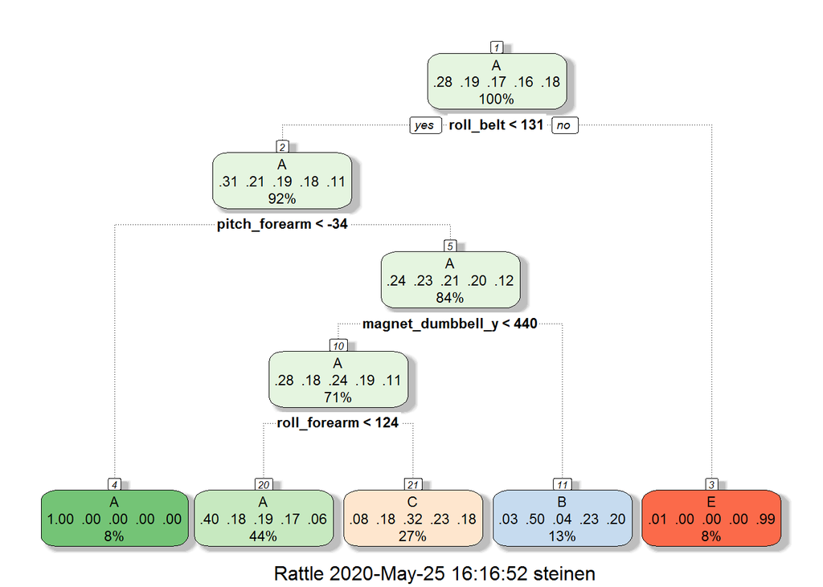

```r
fancyRpartPlot(modFit0$finalModel)
```

### Random forest

```r
library(randomForest, warn.conflicts = FALSE)
modFit1 <- randomForest(classe ~., data = training_new, importance = FALSE)
pred1 <- predict(modFit1, cross_valid)
confusionMatrix(pred1, cross_valid$classe)$overall["Accuracy"]
```

```
##  Accuracy
## 0.9967374
```

### Boosting

```r
modFit2 <- train(classe ~., method ="gbm", data=training_new, verbose = FALSE)
pred2 <- predict(modFit2, cross_valid)
confusionMatrix(pred2, cross_valid$classe)$overall["Accuracy"]
```

```
##  Accuracy
## 0.9618679
```

### Linear discriminant analysis

```r
modFit3 <- train(classe ~., method ="lda", data=training_new)
pred3 <- predict(modFit3, cross_valid)
confusionMatrix(pred3, cross_valid$classe)$overall["Accuracy"]
```

```
##  Accuracy
## 0.6988173
```

## RandomForest model of testing dataset

The random forest model is applied to the testing dataset and the results of the prediction is printed. The decreasing importance of the variables is shown below.

```r
predTest <- predict(modFit1, testing)
predTest
```

```
##  1  2  3  4  5  6  7  8  9 10 11 12 13 14 15 16 17 18 19 20
##  B  A  B  A  A  E  D  B  A  A  B  C  B  A  E  E  A  B  B  B
## Levels: A B C D E
```

```r
names(testing[,order(importance(modFit1), decreasing = TRUE)])
```

```
##  [1] "roll_belt"            "yaw_belt"             "magnet_dumbbell_z"
##  [4] "pitch_forearm"        "pitch_belt"           "magnet_dumbbell_y"
##  [7] "roll_forearm"         "magnet_dumbbell_x"    "accel_belt_z"
## [10] "accel_dumbbell_y"     "magnet_belt_y"        "magnet_belt_z"
## [13] "roll_dumbbell"        "roll_arm"             "accel_dumbbell_z"
## [16] "gyros_belt_z"         "accel_forearm_x"      "magnet_forearm_z"
## [19] "total_accel_dumbbell" "magnet_arm_x"         "yaw_dumbbell"
## [22] "accel_forearm_z"      "magnet_belt_x"        "gyros_dumbbell_y"
## [25] "yaw_arm"              "accel_dumbbell_x"     "accel_arm_x"
## [28] "total_accel_belt"     "magnet_forearm_y"     "magnet_arm_y"
## [31] "magnet_forearm_x"     "magnet_arm_z"         "pitch_arm"
## [34] "yaw_forearm"          "pitch_dumbbell"       "accel_arm_y"
## [37] "accel_forearm_y"      "gyros_arm_y"          "accel_arm_z"
## [40] "gyros_arm_x"          "gyros_dumbbell_x"     "gyros_forearm_y"
## [43] "accel_belt_y"         "total_accel_forearm"  "accel_belt_x"
## [46] "gyros_belt_y"         "total_accel_arm"      "gyros_belt_x"
## [49] "gyros_forearm_z"      "gyros_dumbbell_z"     "gyros_forearm_x"
## [52] "gyros_arm_z"
```